# Задачи по Эконометрике: Мультиколлинеарность

Н.В. Артамонов (МГИМО МИД России)

# 1 sleep equation #1

Для набора данных `sleep75` рассмотрим линейную регрессию **sleep ~ 1 + I(totwrk/100) + I(totwrk^2/10000) + age + smsa + , male**.

Вычислите на VIF для регрессоров

```
    I(totwrk/100) I(totwrk^2/10000)               age              smsa
         8.370495          8.199290          1.005968          1.004459
             male
         1.169198
```

Вычислите корреляционную матриц для регрессоров

```
                  I(totwrk/100) I(totwrk^2/10000)    age   smsa  male
I(totwrk/100)             1.000             0.937 -0.050 -0.038 0.376
I(totwrk^2/10000)         0.937             1.000 -0.046 -0.051 0.351
age                      -0.050            -0.046  1.000  0.025 0.032
smsa                     -0.038            -0.051  0.025  1.000 0.007
male                      0.376             0.351  0.032  0.007 1.000
```

и визуализируйте её

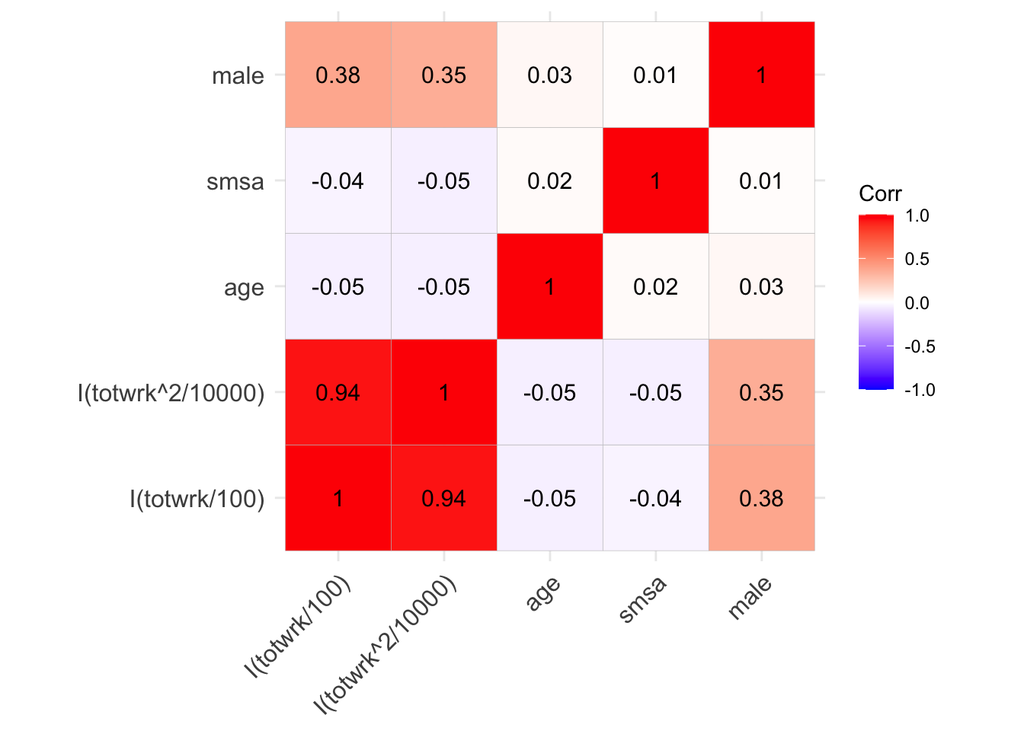

Уровень значимости 5%. Какие коэффициенты значимы (неробастный t-тест)? Ответ

```
[1] "age"  "smsa" "male"
```

Тестируется значимость влияния занятости, т.е. гипотеза $H_0:\beta_{totwrk/100}=\beta_{totwrk^2/10000}=0$. Результаты тестирования (неробастный тест):

```
==============
F      Pr(> F)
--------------
45.619    0
--------------
```

Вычислите необходимое критическое значение. **Ответ округлите до 2-х десятичных знаков.**

```
[1] 3.01
```

Какие результаты тестирования? Ответ

```
[1] "Гипотеза отвергается"
```

**На первый взгляд противоречие.** Оно объясняется мультиколлинеарностью

# 2 sleep equation #2

Для набора данных `sleep75` рассмотрим линейную регрессию **sleep ~ totwrk + age + I(age^2) + smsa + male + union**.

Вычислите на VIF для регрессоров

```
   totwrk       age  I(age^2)      smsa      male     union
 1.195469 65.397082 65.561373  1.004278  1.171666  1.007332
```

Вычислите корреляционную матриц для регрессоров

```
         totwrk    age I(age^2)   smsa  male  union
totwrk    1.000 -0.050   -0.067 -0.038 0.376  0.002
age      -0.050  1.000    0.992  0.025 0.032 -0.037
I(age^2) -0.067  0.992    1.000  0.024 0.026 -0.042
smsa     -0.038  0.025    0.024  1.000 0.007 -0.039
male      0.376  0.032    0.026  0.007 1.000  0.040
union     0.002 -0.037   -0.042 -0.039 0.040  1.000
```

и визуализируйте её

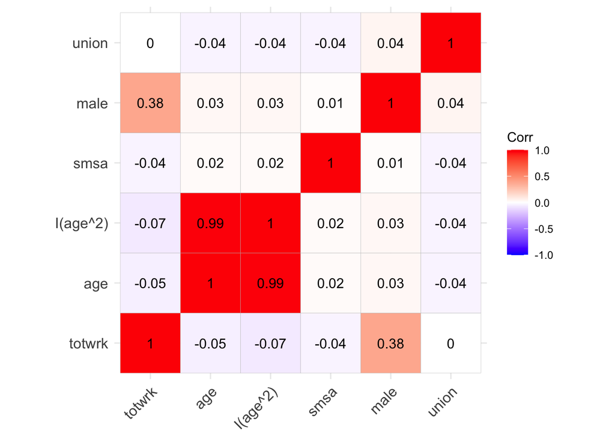

Уровень значимости 5%. Какие коэффициенты значимы (неробастный t-тест)? Ответ

```
[1] "totwrk" "smsa"   "male"
```

Тестируется значимость влияния возраста, т.е. гипотеза $H_0:\beta_{age}=\beta_{age^2}=0$. Результаты тестирования (неробастный тест):

```
=============
F     Pr(> F)
-------------
2.497  0.083
-------------
```

Вычислите необходимое критическое значение. **Ответ округлите до 2-х десятичных знаков.**

```
[1] 3.01
```

Какие результаты тестирования? Ответ

```
[1] "Гипотеза не отвергается"
```

# 3 sleep equation #3

Для набора данных `sleep75` рассмотрим линейную регрессию **sleep ~ totwrk + age + smsa + south + I(totwrk * south) + I(age * , south) + I(smsa * south)**.

Вычислите на VIF для регрессоров

```
           totwrk               age              smsa             south
         1.148498          1.249261          1.187071         22.001994
I(totwrk * south)    I(age * south)   I(smsa * south)
         8.851673         12.277039          1.286230
```

Вычислите корреляционную матриц для регрессоров

```
                  totwrk    age   smsa  south I(totwrk * south) I(age * south)
totwrk             1.000 -0.050 -0.038  0.051             0.175          0.033
age               -0.050  1.000  0.025 -0.018            -0.038          0.126
smsa              -0.038  0.025  1.000 -0.238            -0.224         -0.222
south              0.051 -0.018 -0.238  1.000             0.932          0.947
I(totwrk * south)  0.175 -0.038 -0.224  0.932             1.000          0.868
I(age * south)     0.033  0.126 -0.222  0.947             0.868          1.000
I(smsa * south)    0.012  0.008  0.209  0.359             0.328          0.351
                  I(smsa * south)
totwrk                      0.012
age                         0.008
smsa                        0.209
south                       0.359
I(totwrk * south)           0.328
I(age * south)              0.351
I(smsa * south)             1.000
```

и визуализируйте её

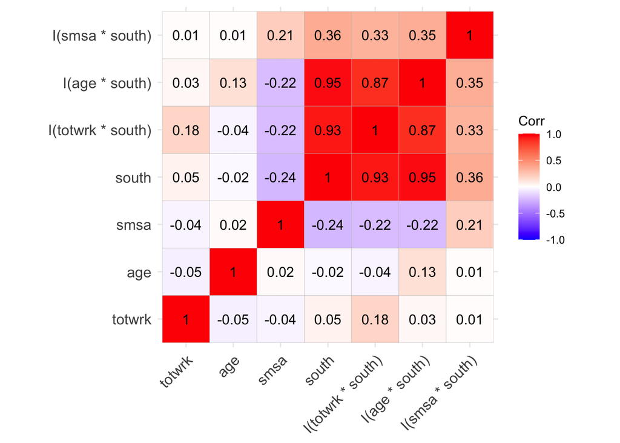

Уровень значимости 5%. Какие коэффициенты значимы (неробастный t-тест)? Ответ

```
[1] "totwrk"         "south"          "I(age * south)"
```

Тестируется значимость влияния влияния географической бинарной переменной, т.е. гипотеза $H_0:\beta_{south}=\beta_{totwrk*south}=\beta_{age * south}=\beta_{smsa * south}=0$. Результаты тестирования (неробастный тест):

```
=============
F     Pr(> F)
-------------
3.144  0.014
-------------
```

Вычислите необходимое критическое значение. **Ответ округлите до 2-х десятичных знаков.**

```
[1] 2.38
```

Какие результаты тестирования? Ответ

```
[1] "Гипотеза отвергается"
```

# 4 wage equation #1

Для набора данных `wage2` рассмотрим линейную регрессию **log(wage) ~ age + I(age^2) + IQ + married + south + urban**.

Вычислите на VIF для регрессоров

```
       age   I(age^2)         IQ    married      south      urban
632.868517 632.964483   1.049260   1.013807   1.061287   1.016749
```

Вычислите корреляционную матриц для регрессоров

```
            age I(age^2)     IQ married  south  urban
age       1.000    0.999 -0.044   0.107 -0.029 -0.007
I(age^2)  0.999    1.000 -0.043   0.107 -0.031 -0.009
IQ       -0.044   -0.043  1.000  -0.015 -0.210  0.039
married   0.107    0.107 -0.015   1.000  0.023 -0.040
south    -0.029   -0.031 -0.210   0.023  1.000 -0.110
urban    -0.007   -0.009  0.039  -0.040 -0.110  1.000
```

и визуализируйте её

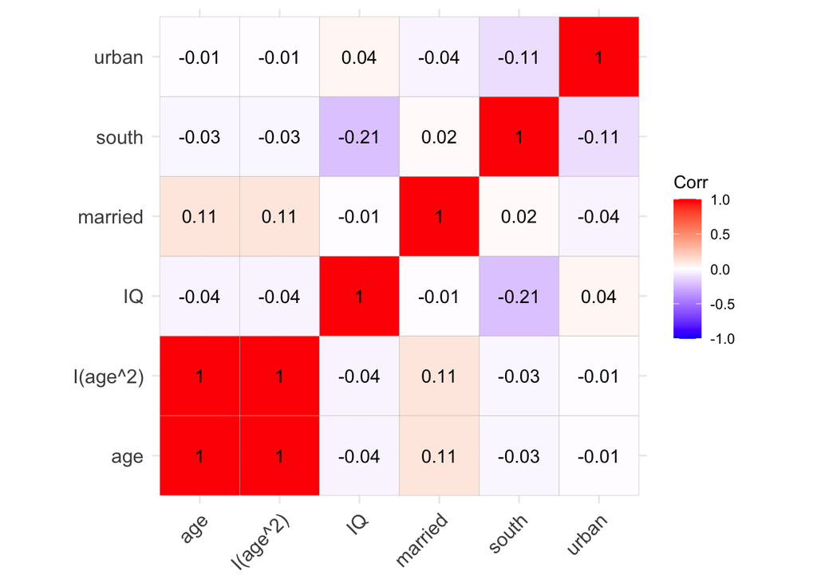

Уровень значимости 5%. Какие коэффициенты значимы (неробастный t-тест)? Ответ

```
[1] "IQ"      "married" "south"   "urban"
```

Тестируется значимость влияния возраста, т.е. гипотеза $H_0:\beta_{age}=\beta_{age^2}=0$. Результаты тестирования (неробастный тест):

```
==============
F      Pr(> F)
--------------
14.833 0.00000
--------------
```

Вычислите необходимое критическое значение. **Ответ округлите до 2-х десятичных знаков.**

```
[1] 3.01
```

Какие результаты тестирования? Ответ

```
[1] "Гипотеза отвергается"
```

**На первый взгляд противоречие.** Оно объясняется мультиколлинеарностью

# 5 wage equation #2 (структурные сдвиги)

Для набора данных `wage2` рассмотрим линейную регрессию **log(wage) ~ age + IQ + south + urban + I(age * urban) + I(IQ * , urban) + I(south * urban)**.

Вычислите на VIF для регрессоров

```
             age               IQ            south            urban
        3.394929         3.879824         3.832146       175.876722
  I(age * urban)    I(IQ * urban) I(south * urban)
      114.318464        53.135490         4.087171
```

Вычислите корреляционную матриц для регрессоров

```
                    age     IQ  south  urban I(age * urban) I(IQ * urban)
age               1.000 -0.044 -0.029 -0.007          0.137        -0.020
IQ               -0.044  1.000 -0.210  0.039          0.030         0.260
south            -0.029 -0.210  1.000 -0.110         -0.106        -0.136
urban            -0.007  0.039 -0.110  1.000          0.985         0.964
I(age * urban)    0.137  0.030 -0.106  0.985          1.000         0.947
I(IQ * urban)    -0.020  0.260 -0.136  0.964          0.947         1.000
I(south * urban)  0.010 -0.097  0.741  0.334          0.332         0.288
                 I(south * urban)
age                         0.010
IQ                         -0.097
south                       0.741
urban                       0.334
I(age * urban)              0.332
I(IQ * urban)               0.288
I(south * urban)            1.000
```

и визуализируйте её

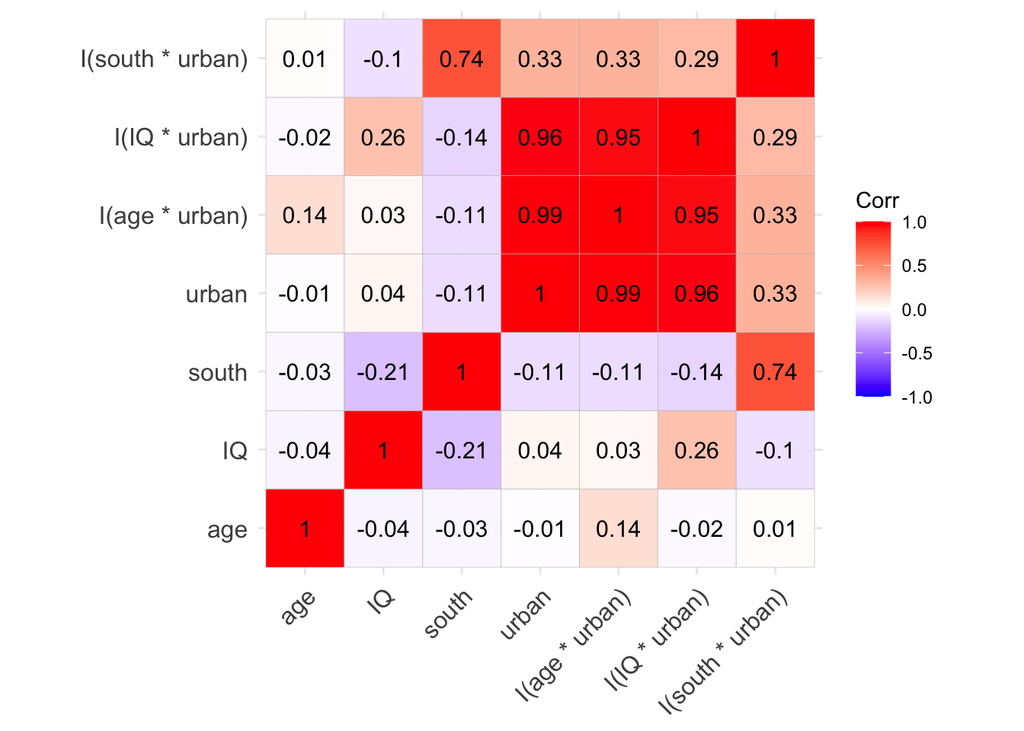

Уровень значимости 1%. Какие коэффициенты значимы (неробастный t-тест)? Ответ

```
[1] "age" "IQ"
```

Тестируется значимость влияния места жительства, т.е. гипотеза $H_0:\beta_{urban}=\beta_{age*urban}=\beta_{IQ*urban}=\beta_{south*urban}=0$ Результаты тестирования (неробастный тест):

```
==============
F      Pr(> F)
--------------
10.250 0.00000
--------------
```

Вычислите необходимое критическое значение. **Ответ округлите до 2-х десятичных знаков.**

```
[1] 3.34
```

Какие результаты тестирования? Ответ

```
[1] "Гипотеза отвергается"
```

**На первый взгляд противоречие.** Оно объясняется мультиколлинеарностью